# Deep Learning Lab II (L06)

Data Science III (STAT 301-3)

May 15th, 2019

# Overview

The main goal of this lab is to continue practicing the application of deep learning techniques using neural networks as implemented through the use of the `keras` and `tensorflow` packages in R.

When creating the Rmd file for this assignment, you won’t want all your code chunks to evaluate because it would take too long to run. You’ll want to produce results, store them in a subdirectory, and then reference them in the Rmd file. You may need to use hidden chunks of code to read in results or use Rmd code to insert graphics that you want to display.

# Datasets

We have split the `wildfires.csv` dataset into a training dataset (`wildfires_train.csv`) and test dataset (`wildfires_test.csv`). They are contained in the **data** subdirectory along with a codebook.

# Exercises

Please complete the following exercises. Be sure your solutions are clearly indicated and that the document is neatly formatted.

#### Load Packages

```r
# Loading package(s)
library(modelr)
library(tensorflow)
use_python("/usr/bin/python")
library(keras)
library(ggplot2)
library(e1071)
library(randomForest)
library(xgboost)
library(glmnet)
library(glmnetUtils)
library(tidyverse)
```

#### Read in data

```r
# read in data
wildfires_train <- read_csv("data/wildfires_train.csv") %>%
  mutate(winddir = factor(winddir, levels = c("N", "NE", "E", "SE", "S", "SW", "W", "NW")),
         traffic = factor(traffic, levels = c("lo", "med", "hi")))
wildfires_test <- read_csv("data/wildfires_test.csv") %>%
  mutate(winddir = factor(winddir, levels = c("N", "NE", "E", "SE", "S", "SW", "W", "NW")),
         traffic = factor(traffic, levels = c("lo", "med", "hi")))
wildfires_all <- bind_rows(wildfires_train, wildfires_test)
wildfires <- tibble(train = wildfires_train %>% list(),
                    test = wildfires_test %>% list())
```

#### Exercise 1

The total area burned by a wildfire is of great concern to government planners. This is captured by the variable `burned` in the `wildfires` dataset. Fit a small neural network, say 3 layers (2 hidden), to predict the total area burned by a wildfire. Consider exploring the use of a smaller or larger network. **Exclude `wlf` as a predictor.**

We previously applied boosting, bagging, and random forests methods to build candidate regression trees to predict the total area burned by a wildfire (`burned`). We also fit a multiple linear regression model that used all appropriate predictors for comparison.

Construct a table displaying the RMSE for the your fitted network(s) and the 3 tree-based models and the multiple regression model from CART Lab II (L04) fit in CART Lab II (L04). Which model is the best?

##### Neural Network

```r
# one-hot encode
burned_onehot <- function(dat){
  dat = as_tibble(dat)
  mat = wildfires_all %>%
    dplyr::select(-c(burned, wlf)) %>%
    onehot::onehot() %>%
    predict(dat)
  return(mat)
}
# prepare the data
burned_train_data <- burned_onehot(wildfires_train)
burned_train_targets <- as.matrix(wildfires_train[,"burned"])
burned_test_data <- burned_onehot(wildfires_test)
burned_test_targets <- as.matrix(wildfires_test[,"burned"])
# scale the data
burned_train_data <- scale(burned_train_data)
burned_test_data <- scale(burned_test_data)

# build the network
build_burned_model <- function() {
  model <- keras_model_sequential() %>%
    layer_dense(units = 16, activation = "relu", input_shape = dim(burned_train_data)[[2]]) %>%
    layer_dense(units = 16, activation = "relu") %>%
    layer_dense(units = 1)
  model %>%
    compile(optimizer = "rmsprop",
            loss = "mse",
            metrics = c("mse"))
}
```

```r
# k-fold cross validation
set.seed(1)
k <- 4
indices <- sample(1:nrow(burned_train_data))
folds <- cut(1:length(indices), breaks = k, labels = FALSE)
all_mse_histories <- NULL
for (i in 1:k) {
  cat("processing fold #", i, "\n")
  # Prepare the validation data: data from partition # k
  val_indices <- which(folds == i, arr.ind = TRUE)
  val_data <- burned_train_data[val_indices,]
  val_targets <- burned_train_targets[val_indices]

  # Prepare the training data: data from all other partitions
  partial_train_data <- burned_train_data[-val_indices,]
  partial_train_targets <- burned_train_targets[-val_indices]

  # Build the Keras model (already compiled)
  burned_model <- build_burned_model()

  # Train the model (in silent mode, verbose=0)
  burned_history <- burned_model %>%
    fit(partial_train_data, partial_train_targets,
        validation_data = list(val_data, val_targets),
        epochs = 100, batch_size = 1, verbose = 0)
  mse_history <- burned_history$metrics$val_mean_squared_error
  all_mse_histories <- rbind(all_mse_histories, mse_history)
}
```

```
## processing fold # 1
## processing fold # 2
## processing fold # 3
## processing fold # 4
```

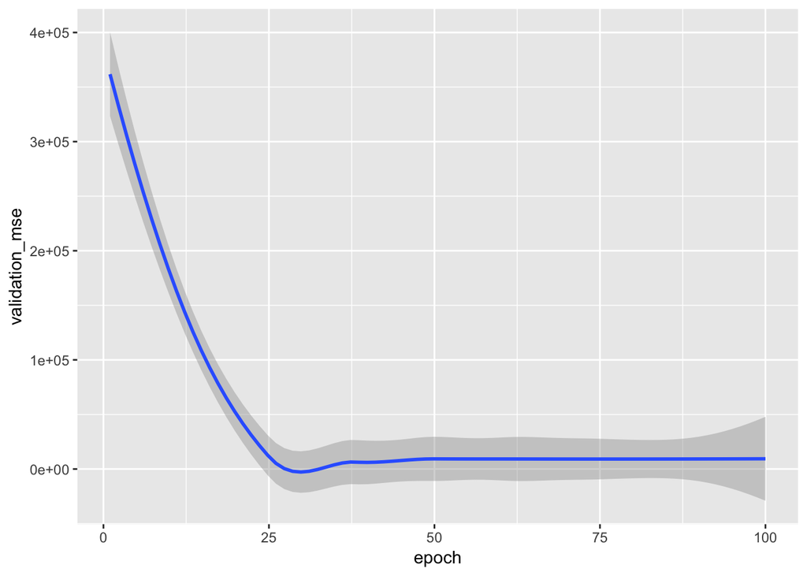

```r
# compute the average of the per-epoch MSE scores for all folds
average_mse_history <- data.frame(
  epoch = seq(1:ncol(all_mse_histories)),
  validation_mse = apply(all_mse_histories, 2, mean))
# get a clearer picture
ggplot(average_mse_history, aes(x = epoch, y = validation_mse)) + geom_smooth()
```

```r
# Build the final model
burned_model <- build_burned_model()
# Train the model (in silent mode, verbose=0)
burned_model %>% fit(burned_train_data, burned_train_targets,
                epochs = 27, batch_size = 1, verbose = 0)
# Evaluate the model on the testing data
burned_results <- burned_model %>% evaluate(burned_test_data, burned_test_targets, verbose = 0)
burned_nn_rmse <- sqrt(burned_results$mean_squared_error)
burned_nn_rmse
```

```
## [1] 101.5936
```

##### Other models - Tree

```r
# helper function
xg_rmse <- function(model, test){
  preds = predict(model, test)
  vals = getinfo(test, "label")
  return(sqrt(mean((preds - vals)^2)))
}
# boosting
burned_Boosting <- tibble(train = xgb.DMatrix(data = burned_train_data, label = burned_train_targets)
                          %>% list(),
                          test = xgb.DMatrix(data = burned_test_data, label = burned_test_targets)
                          %>% list()) %>%
  mutate(model = map2(train, 5000, xgb.train,
                      params = list(eta = 0.01, max_depth = 10)),
         Boosting = map2_dbl(model, test, xg_rmse)) %>%
  gather(key = "Model", value = "RMSE", Boosting) %>%
  select(Model, RMSE)
# bagging
burned_Bagging <- wildfires %>%
  mutate(model = map2(.x = train, .y = 15, ~randomForest(burned ~ . - wlf, data = .x, mtry = .y)),
         Bagging = map2_dbl(model, test, rmse)) %>%
  gather(key = "Model", value = "RMSE", Bagging) %>%
  select(Model, RMSE)
# random forests
burned_RandomForest <- wildfires %>%
  mutate(model = map2(.x = train, .y = 6, ~randomForest(burned ~ . - wlf, data = .x, mtry = .y)),
         RandomForest = map2_dbl(model, test, rmse)) %>%
  gather(key = "Model", value = "RMSE", RandomForest) %>%
  select(Model, RMSE)
```

##### Other models - Ridge & Linear regression

```r
# ridge
burned_Ridge <- wildfires %>%
  mutate(model = map(train, ~glmnet(burned ~ .- wlf, data = .x, alpha = 0, lambda = 3.45)),
         pred = map2(model, test, predict),
         Ridge = map2_dbl(test, pred, ~sqrt( mean((.x$burned - .y)^2)))) %>%
  gather(key = "Model", value = "RMSE", Ridge) %>%
  select(Model, RMSE)
# linear regression
Linear <- wildfires %>%
  mutate(model = map(train, ~lm(burned ~ .-wlf, data = .x)),
         Linear = map2_dbl(model, test, rmse)) %>%
  gather(key = "Model", value = "RMSE", Linear) %>%
  select(Model, RMSE)
```

##### Compare the RMSE

```r
burned_NN <- tibble(Model = "NeuralNetwork",
                    RMSE = burned_nn_rmse)
compare_rmse <- burned_Bagging %>%
  bind_rows(burned_RandomForest) %>%
  bind_rows(burned_Boosting) %>%
  bind_rows(burned_Ridge) %>%
  bind_rows(Linear) %>%
  bind_rows(burned_NN) %>%
  arrange(RMSE)
compare_rmse
```

```
## # A tibble: 6 x 2
##   Model          RMSE
##   <chr>         <dbl>
## 1 Linear         83.4
## 2 Ridge          83.5
## 3 Bagging        99.1
## 4 RandomForest   99.5
## 5 NeuralNetwork 102.
## 6 Boosting      104.
```

#### Exercise 2

Our goal is to predict whether a wildfire will reach the wildlife protection zone, as determined by the indicator variable `wlf`. Fit a small neural network, say 3 layers (2 hidden), to predict whether or not a wildfire with reach the wildfire protection zone. Consider exploring the use of a smaller or larger network.

Previously we utilized boosting, bagging, and random forests methods to build a candidate classification trees that predict whether a wildfire will reach this zone. We also benchmarked those methods against a multiple linear logistic model that utilized all predictors for comparison — CART Lab II (L04). We also previously fit a support vector classifier and 2 support vector machines in SVM Lab II (L07).

Construct a table displaying the test error for the your fitted network(s), the 3 tree-based models and the multiple regression model from CART Lab II (L04) fit in CART Lab II (L04), and the 3 models fit in SVM Lab II (L07). Which model is the best?

##### Neural network

```r
# one-hot encode
wlf_onehot <- function(dat){
  dat = as_tibble(dat)
  mat = wildfires_all %>%
    dplyr::select(-c(wlf)) %>%
    onehot::onehot() %>%
    predict(dat)
  return(mat)
}
# prepare the data
wlf_train_data <- wlf_onehot(wildfires_train)
wlf_train_label <- as.matrix(wildfires_train[,"wlf"])
wlf_test_data <- wlf_onehot(wildfires_test)
wlf_test_label <- as.matrix(wildfires_test[,"wlf"])
# scale the data
wlf_train_data <- scale(wlf_train_data)
wlf_test_data <- scale(wlf_test_data)

# build the network
build_wlf_model <- function() {
  model <- keras_model_sequential() %>%
    layer_dense(units = 16, activation = "relu", input_shape = dim(wlf_train_data)[[2]]) %>%
    layer_dense(units = 16, activation = "relu") %>%
    layer_dense(units = 1, activation = "sigmoid")
  model %>%
    compile(optimizer = "rmsprop",
            loss = "binary_crossentropy",
            metrics = c("accuracy"))
}
```

```r
# k-fold cross validation
set.seed(1)
k <- 4
indices <- sample(1:nrow(wlf_train_data))
folds <- cut(1:length(indices), breaks = k, labels = FALSE)
all_err_histories <- NULL
for (i in 1:k) {
  cat("processing fold #", i, "\n")
  # Prepare the validation data: data from partition # k
  val_indices <- which(folds == i, arr.ind = TRUE)
  val_data <- wlf_train_data[val_indices,]
  val_label <- wlf_train_label[val_indices]

  # Prepare the training data: data from all other partitions
  partial_train_data <- wlf_train_data[-val_indices,]
  partial_train_label <- wlf_train_label[-val_indices]

  # Build the Keras model (already compiled)
  wlf_model <- build_wlf_model()

  # Train the model (in silent mode, verbose=0)
  wlf_history <- wlf_model %>%
    fit(partial_train_data, partial_train_label,
        validation_data = list(val_data, val_label),
        epochs = 100, batch_size = 1, verbose = 0)
  err_history <- 1 - wlf_history$metrics$val_acc
  all_err_histories <- rbind(all_err_histories, err_history)
}
```

```
## processing fold # 1
## processing fold # 2
## processing fold # 3
## processing fold # 4
```

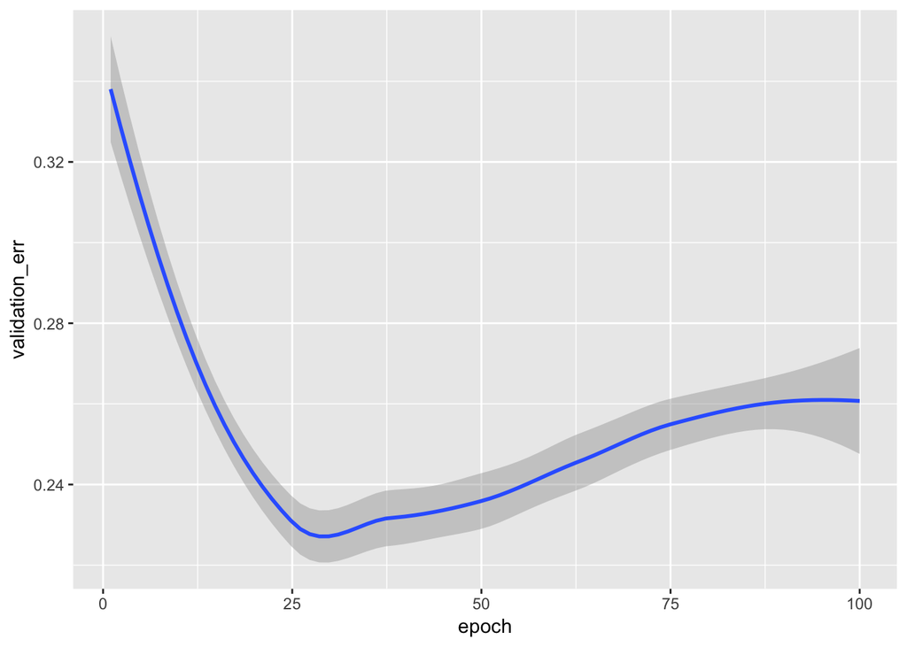

```r
# compute the average of the per-epoch MSE scores for all folds
average_err_history <- data.frame(
  epoch = seq(1:ncol(all_err_histories)),
  validation_err = apply(all_err_histories, 2, mean))
# get a clearer picture
ggplot(average_err_history, aes(x = epoch, y = validation_err)) + geom_smooth()
```

```r
# Build the final model
wlf_model <- build_wlf_model()
# Train the model (in silent mode, verbose=0)
wlf_model %>% fit(wlf_train_data, wlf_train_label,
                epochs = 25, batch_size = 1, verbose = 0)
# Evaluate the model on the testing data
wlf_results <- wlf_model %>% evaluate(wlf_test_data, wlf_test_label, verbose = 0)
wlf_nn_error <- 1 - wlf_results$acc
wlf_nn_error
```

```
## [1] 0.1733333
```

##### Other models - SVM

```r
wildfire_train <- wildfires_train
wildfire_test <- wildfires_test
wildfire_train$wlf <- as.factor(wildfires_train$wlf)
wildfire_test$wlf <- as.factor(wildfires_test$wlf)
wildfire <- tibble(train = wildfire_train %>% list(),
                    test = wildfire_test %>% list())
# linear SVM
svm_linear <- wildfire %>%
  mutate(model_fit = map(.x = train, # fit the model
                         .f = function(x) svm(wlf ~ ., data = x,  kernel = "linear",
                                              cost = 0.5, probability = TRUE)),
         test_pred = map2(model_fit, test,
                          ~ predict(.x, .y, probability = TRUE)), # get predictions on test set
         confusion_matrix = map2(.x = test, .y = test_pred,  # get confusion matrix
                                 .f = function(x, y) caret::confusionMatrix(x$wlf, y)),
         SVM_Linear = 1- confusion_matrix[[1]]$overall[[1]]) %>%
  gather(key = "Model", value = "ERROR", SVM_Linear) %>%
  select(Model, ERROR)
# radial SVM
svm_radial <- wildfire %>%
  mutate(model_fit = map(.x = train,
                         .f = function(x) svm(wlf ~ ., data = x, kernel = "radial",
                                              cost = 8, gamma = 0.05, probability = TRUE)),
         test_pred = map2(model_fit, test, ~ predict(.x, .y, probability = TRUE)), # test predcitions
         confusion_matrix = map2(.x = test, .y = test_pred, # test confusion matrix
                               .f = function(x, y) caret::confusionMatrix(x$wlf, y)),
         SVM_Radial = 1- confusion_matrix[[1]]$overall[[1]]) %>%
  gather(key = "Model", value = "ERROR", SVM_Radial) %>%
  select(Model, ERROR)
# polynomial SVM
svm_polynominal <- wildfire %>%
  mutate(model_fit = map(.x = train,
                         .f = function(x) svm(wlf ~ ., data = x, kernel = "polynomial",
                                              cost = 0.01, gamma = 4, degree = 2, probability = TRUE)),
         test_pred = map2(model_fit, test, ~ predict(.x, .y, probability = TRUE)), # test predcitions
         confusion_matrix = map2(.x = test, .y = test_pred, # test confusion matrix
                               .f = function(x, y) caret::confusionMatrix(x$wlf, y)),
         SVM_Polynomial = 1- confusion_matrix[[1]]$overall[[1]]) %>%
  gather(key = "Model", value = "ERROR", SVM_Polynomial) %>%
  select(Model, ERROR)
```

##### Other models - Tree

```r
# helper function
xg_err <- function(model, test){
  prob = predict(model, test, type = "response")
  vals = getinfo(test, "label")
  pred <- factor(if_else(prob > 0.5, 1, 0))
  mean(vals != pred)
}
test_err <- function(mod_fit, df){
  prob <- predict(mod_fit, newdata = df, type = "response")
  pred <- factor(if_else(prob > 0.5, 1, 0))
  return(mean(df$wlf != pred))
}
# boosting
wlf_Boosting <- tibble(train = xgb.DMatrix(data = wlf_train_data, label = wlf_train_label) %>% list(),
                   test = xgb.DMatrix(data = wlf_test_data, label = wlf_test_label) %>% list()) %>%
  mutate(model = map2(train, 5000, xgb.train,
                      params = list(eta = 0.09, max_depth = 10)),
         Boosting = map2_dbl(model, test, xg_err)) %>%
  gather(key = "Model", value = "ERROR", Boosting) %>%
  select(Model, ERROR)
# bagging
wlf_Bagging <- wildfires %>%
  mutate(model = map2(.x = train, .y = 16, ~randomForest(wlf ~ ., data = .x, mtry = .y)),
         Bagging = map2_dbl(model, test, test_err)) %>%
  gather(key = "Model", value = "ERROR", Bagging) %>%
  select(Model, ERROR)
# random forests
wlf_RandomForest <- wildfires %>%
  mutate(model = map2(.x = train, .y = 7, ~randomForest(wlf ~ ., data = .x, mtry = .y)),
         RandomForest = map2_dbl(model, test, test_err)) %>%
  gather(key = "Model", value = "ERROR", RandomForest) %>%
  select(Model, ERROR)
```

##### Other models - ridge & logistic

```r
# ridge
wlf_Ridge <- wildfires %>%
  mutate(model = map(.x = train, ~glmnet(wlf ~ ., data = .x, alpha = 0, lambda = 3.37)),
         Ridge = map2_dbl(model, test, test_err)) %>%
  gather(key = "Model", value = "ERROR", Ridge) %>%
  select(Model, ERROR)
# logistic regression
Logistic <- wildfires %>%
  mutate(model = map(.x = train, ~glm(wlf ~., data = .x, family = binomial)),
         Logistic = map2_dbl(model, test, test_err)) %>%
  gather(key = "Model", value = "ERROR", Logistic) %>%
  select(Model, ERROR)
```

```r
wlf_NN <- tibble(Model = "NeuralNetwork",
                    ERROR = wlf_nn_error)
compare_error <- wlf_Bagging %>%
  bind_rows(wlf_RandomForest) %>%
  bind_rows(wlf_Boosting) %>%
  bind_rows(wlf_Ridge) %>%
  bind_rows(Logistic) %>%
  bind_rows(wlf_NN) %>%
  bind_rows(svm_linear) %>%
  bind_rows(svm_radial) %>%
  bind_rows(svm_polynominal) %>%
  arrange(ERROR)
compare_error
```

```
## # A tibble: 9 x 2
##   Model          ERROR
##   <chr>          <dbl>
## 1 NeuralNetwork  0.173
## 2 RandomForest   0.18
## 3 Bagging        0.193
## 4 SVM_Radial     0.207
## 5 SVM_Polynomial 0.227
## 6 SVM_Linear     0.233
## 7 Ridge          0.247
## 8 Logistic       0.247
## 9 Boosting       0.293
```